# Seminar Tema 3

Minstelønn og fagforeninger

Author

Andrea Mannberg

## Oppgave 1a: Minstelønn under fullkommen konkurranse

Anta at etterspørselen på arbeid er gitt ved:

$$L^D = \frac{E}{\alpha}-\frac{1}{\alpha}w$$
Og at tilbudet av arbeid gis av:

$$L^S =- \frac{T}{\beta}+\frac{1}{\beta}\cdot w$$

Der $E = 250$ $\alpha = 0.5$, $T = 10$ og $\beta = 0.5$

- Gå ut ifra at markedet er karakterisert av fullkommen konkurranse. Utled lønn og sysselsetting på dette markedet. Illustrer grafisk.
- Tenk deg nå at regjeringa innfører en minstelønn på 150 NOK. Hva skjer med lønn og sysselsetting på markedet?

## Likvekt uten minstelønn under FK

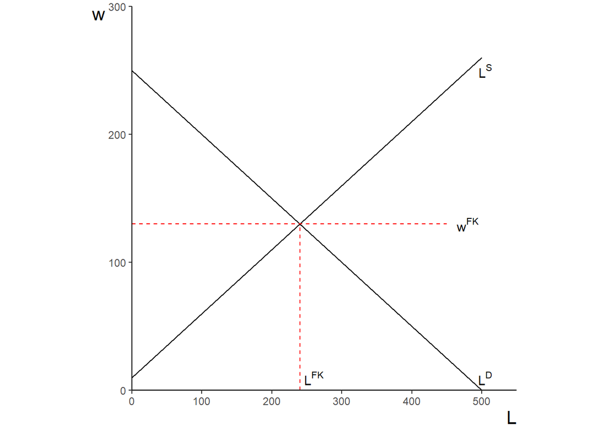

## Likvekt med minstelønn under FK

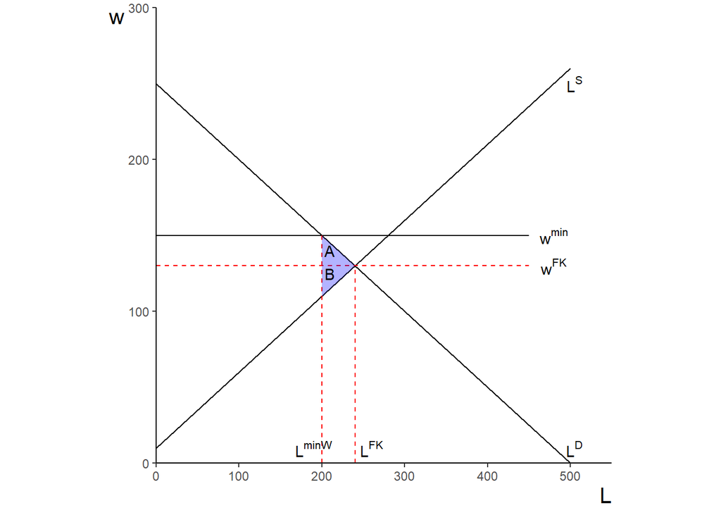

## Oppgave 1b: Minstelønn under monopsoni

Anta at etterspørselen på arbeid er gitt ved:

$$L^D = \frac{E}{\alpha}-\frac{1}{\alpha}w$$
Og at tilbudet av arbeid gis av:

$$L^S = -\frac{T}{\beta}+\frac{1}{\beta}\cdot w$$

Der $E = 250$ $\alpha = 0.5$, $T = 10$ og $\beta = 0.5$

- Anta nå at det kun er én arbeidsgiver på markedet som etterspør arbeid. Bedriften er pristaker på godemarkedet. Utled matematisk og illustrer grafisk hva sysselsetting og lønn ville ha vært i likevekt **uten minstelønn** hadde vært i denne situasjonen.
- Illustrer grafisk effekten av å introdusere en minstelønn på 150 NOK i dette tilfellet (du trenger ikke å utlede dette matematisk da dette krever bruk av Kuhn-Tucker vilkår).

## Likvekt uten minstelønn under monopsoni

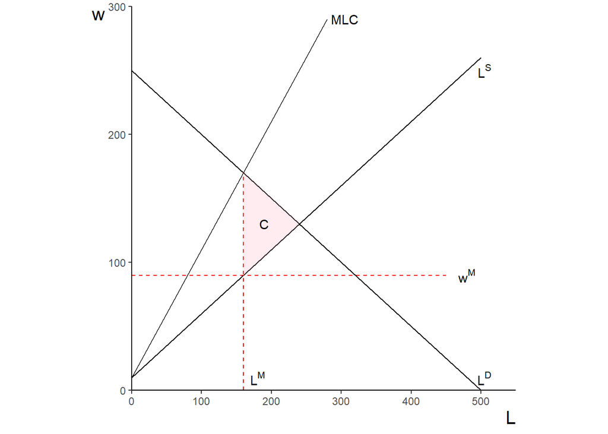

## Likevekt under monopsoni og minstelønn

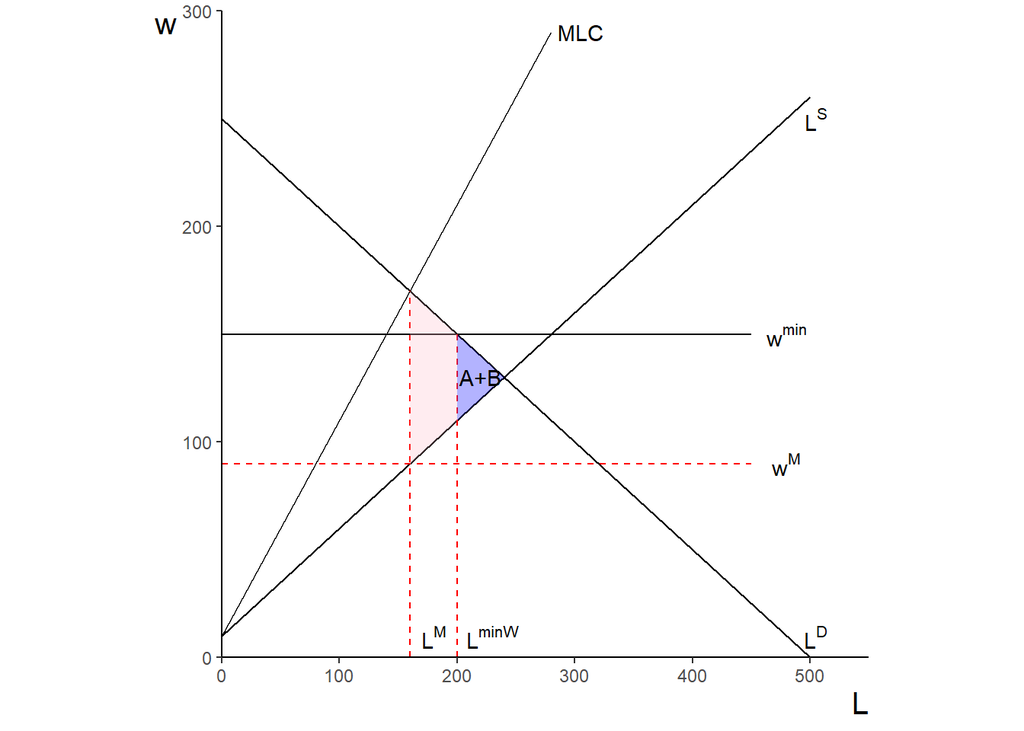

## Oppgave 2 - Fagforeningsmonopol

Anta at markedets etterspørsel på arbeid er gitt ved:
$$w = 800 - 0.08\cdot L$$

Der $w$ er reallønn og $L$ er antall sysselsattte. Anta at alle arbeidere er organisert i en fagforening. Fagforeningen sitt mål er å maksimere den summerte nytten blant medlemmene.

Anta at fagforeningen sin nyttefunksjon er gitt ved:

$$U^F = (w-w^r) \cdot L$$

Der $w^r = 100$ er reservasjonslønna som vi antar er lik for alle arbeider.

Anta at fagforeningen har monopol på arbeidsmarkedet og at det ikke er forhandling. Arbeidsgiverne er pristakere.

- Utled matematisk, illustrer grafisk og gi økonomisk intuisjon til den lønn som fagforeningen vil sette dersom den maksimerer nytten til medlemmene sine. Beregne nivå på sysselsetting.

## Figur 5

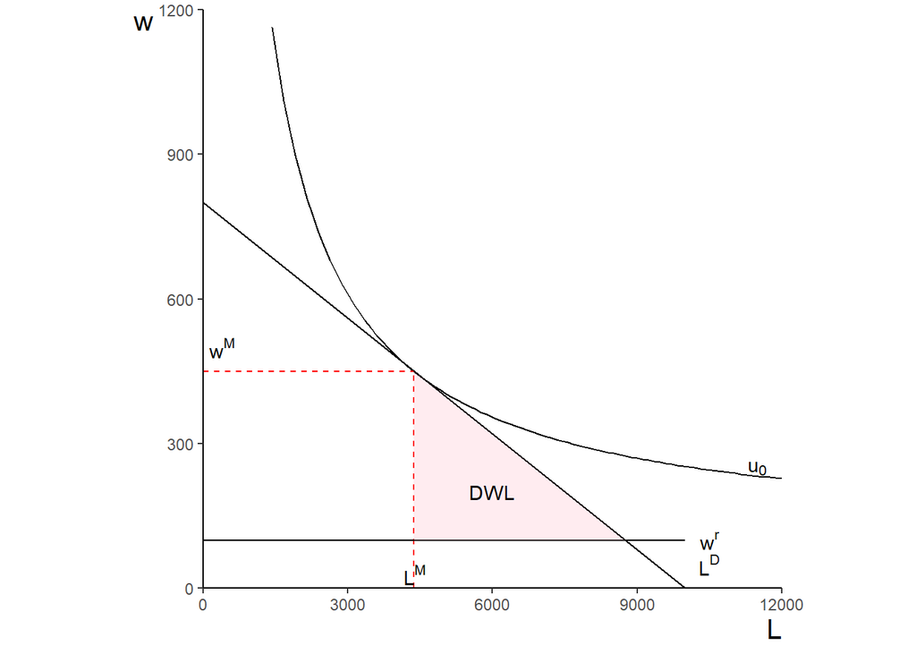